# 01. Visualization with 'matplotlib'

- originated from MATLAB's visualization
- 2D line-plot, scatter-plot, bar-chart, histogram, pie-chart
- ref. url : http://matplotlib.org/

```python
import matplotlib.pyplot as plt
```

## Line Graph

### show graphs INLINE or NOT

Spyder>IPython Console or Jupyter Notebook Code Cell

- show graph on another pop-up window
  - %matplotlib qt
- show graph among code cells
  - %matplotlib inline

```python
%matplotlib inline
```

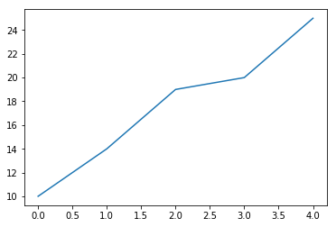

```python
data1 = [10,14,19,20,25]
plt.plot(data1)
```

- if input of plt.plot() is just one array sequence, the value of array sequence is shown on the y-axis

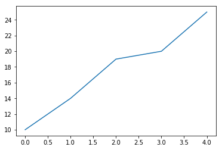

```python
# show graph on another pop-up window
%matplotlib qt

data1 = [10,14,19,20,25]
plt.plot(data1)
```

```python
# reset to show graph in code shells
%matplotlib inline
```

### 2-Dimension line graph (x,y)

```python
import numpy as np

x = np.arange(-4.5,5,0.5)
y = 2*x**2

[x,y]
```

```
[array([-4.5, -4. , -3.5, -3. , -2.5, -2. , -1.5, -1. , -0.5,  0. ,  0.5,
         1. ,  1.5,  2. ,  2.5,  3. ,  3.5,  4. ,  4.5]),
 array([40.5, 32. , 24.5, 18. , 12.5,  8. ,  4.5,  2. ,  0.5,  0. ,  0.5,
         2. ,  4.5,  8. , 12.5, 18. , 24.5, 32. , 40.5])]
```

```python
import numpy as np

x = np.arange(-4.5,5,0.5)
y = 2*x**2

type(x), type(y)
```

```
(numpy.ndarray, numpy.ndarray)
```

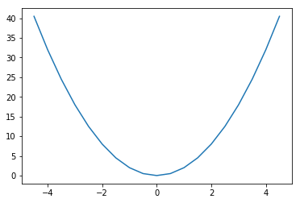

```python
import numpy as np

x = np.arange(-4.5,5,0.5)
y = 2*x**2

plt.plot(x,y)
plt.show()
```

- if the inputs of plt.plot() are two different array sequence, each x and y values are shown on x-axis and y-axis respectively

### multiple plots

```python
import numpy as np
import matplotlib.pyplot as plt

x = np.arange(-4.5, 5, 0.5)
y1 = 2*x**2
y2 = 5*x + 30
y3 = 4*x**2 + 10
```

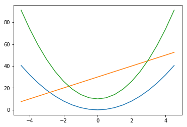

```python
import numpy as np
import matplotlib.pyplot as plt

x = np.arange(-4.5, 5, 0.5)
y1 = 2*x**2
y2 = 5*x + 30
y3 = 4*x**2 + 10

plt. plot(x,y1)
plt. plot(x,y2)
plt. plot(x,y3)
plt.show()
```

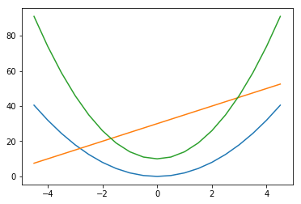

```python
import numpy as np
import matplotlib.pyplot as plt

x = np.arange(-4.5, 5, 0.5)
y1 = 2*x**2
y2 = 5*x + 30
y3 = 4*x**2 + 10

plt.plot(x, y1, x, y2, x, y3)  # multi plots (another way)
plt.show()
```

#### draw another graph on another layout(=figure)

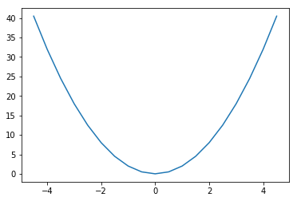

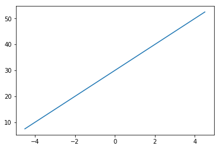

```python
import numpy as np
import matplotlib.pyplot as plt

x = np.arange(-4.5, 5, 0.5)
y1 = 2*x**2
y2 = 5*x + 30
y3 = 4*x**2 + 10

plt.plot(x,y1)
plt.figure()
plt.plot(x,y2)
plt.show()
```

```python
# close the figure
plt.close()
```

clear all graph on the figure

- plt.clf()
- plt.figure(N) : select(or indicate)d figure no.N

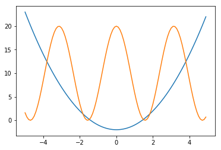

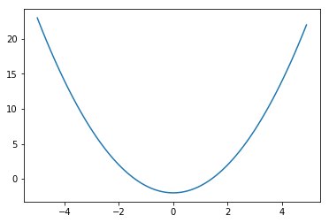

```python
import numpy as np
import matplotlib.pyplot as plt

# generate data
x = np.arange(-5,5,0.1)
y1 = x**2 - 2
y2 = 20 * np.cos(x)**2

plt.figure(1)    #generate space no.1
plt.plot(x, y1)  #draw graph_01 on no.1 figure

plt.figure(2)    #generate space no.2
plt.plot(x,y2)   #draw graph_02 on no.2 figure

plt.figure(1)    #indicate space no.1
plt.plot(x,y2)   #draw one more graph(graph_02) on no.1 figure

plt.figure(2)    #indicate space no.2
plt.clf()        #clear all graphs on no.2 figure
plt.plot(x,y1)   #draw graph_01 on no.2 figure

plt.show()
```